# Laboratorio Del Sole

## Progetto di artigianato di Noemi Fain

Analisi: autunno 2023 - estate 2026

# Introduzione

## Da dove è nato?

### La storia

- Nell'estate del 2022 comprai del filo di rame per sperimentare una tecnica di realizzazione di gioielli.
- Nel 2023 amici e parenti mi chiesero le prime commissioni.
- Nel giugno del 2024 partecipai al primo mercatino.

### L'obiettivo

Realizzare qualcosa di durevole ed esteticamente piacevole in un materiale tradizionale.

## Domande

- Come si distribuiscono le vendite rispetto alle stagioni?
- Quali tipi vendono di più?
- Quale mercatino mi ha impegnato di più? Dove?
- Quanti di questi gioielli hanno un disegno originale?
- Quali sono i tipi di gioiello più pesanti? Presenza di perline e origine del design influiscono?
- Le ore di lavoro crescono di pari passo con il peso?
- Il rapporto prezzo / ora è aumentato nel tempo?
- Sono meglio più pezzi piccoli o uno grande?

# I dati utilizzati

## Fonte

Dati privati raccolti tra:

- foto scattate
- riepiloghi dei mercatini
- misurazioni dirette

## Contenuto

Dati sui gioielli: per ognuno dei 83 modelli prodotti

- caratteristiche del gioiello:
  - tipologia (tra ciondoli, orecchini, anelli, bracciali e altro)
  - ore impiegate
  - prezzo di vendita
  - peso (in grammi)
  - se il design è originale
  - se ci sono perline
- storico delle vendite: pezzi rimasti, regalati, mercatini e commissione (autunno 2023 - estate 2026)

Dati sui mercatini: per ognuno dei 5 mercatini fatti

- luogo e coordinate
- durata in giorni
- nome dell'evento

# Domande

## Come si distribuiscono le vendite?

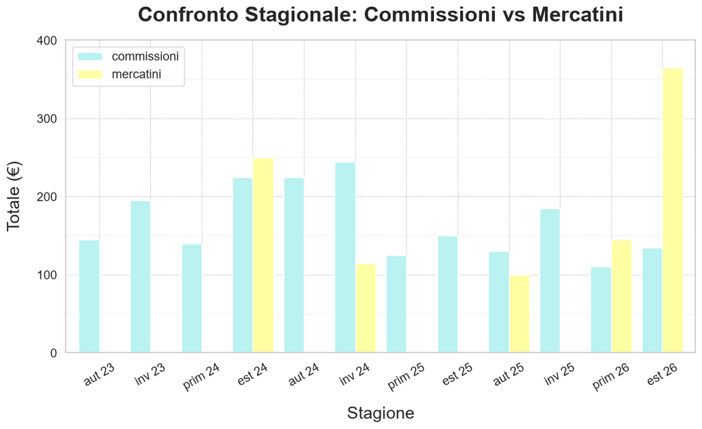

## Quali tipi vendono di più?

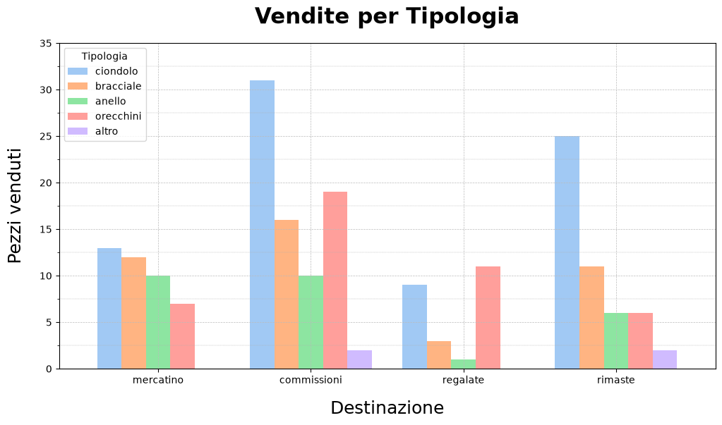

## Quale mercatino mi ha impegnato di più? Dove?

[figure not shown]

## Quanti hanno un disegno originale?

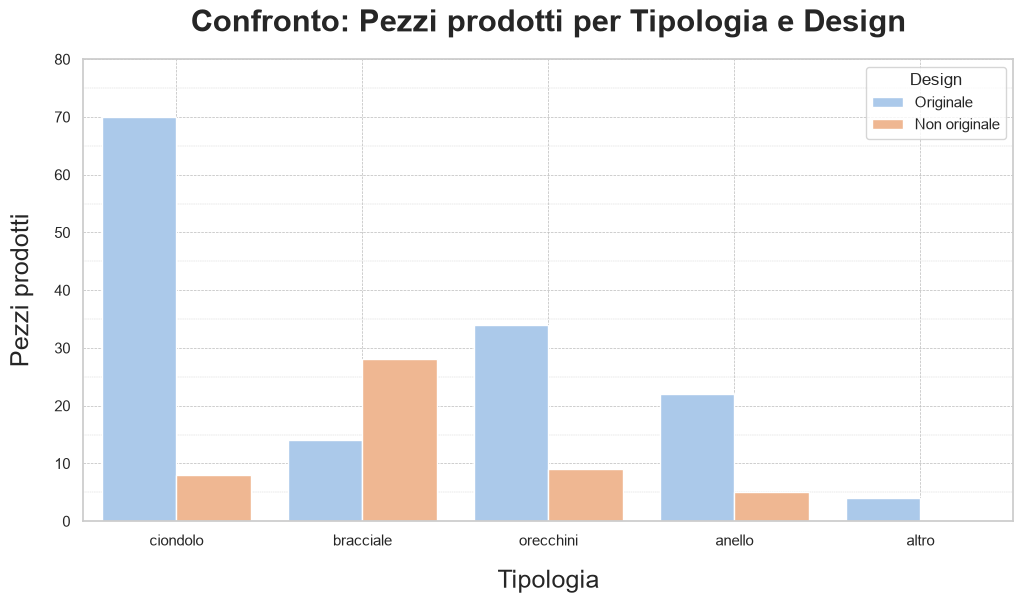

## Quali sono i tipi più pesanti?

Confronto: presenza di perline e origine del design

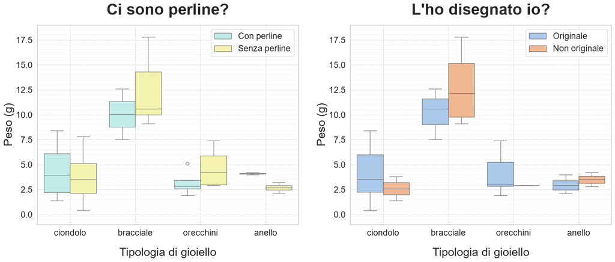

## Il peso è proporzionale alle ore?

Analisi degli oggetti con peso minore a 8.0g

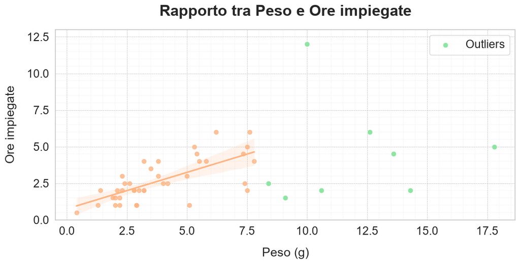

## Il prezzo / ora è aumentato nel tempo?

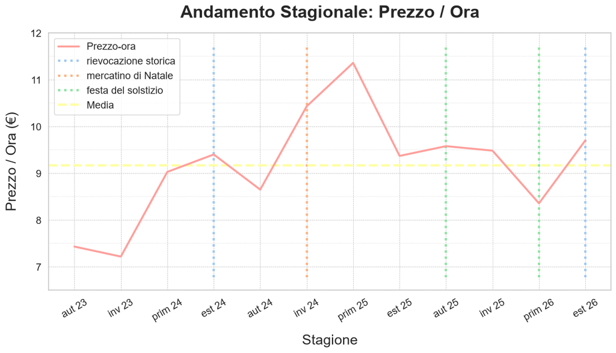

## Meglio più pezzi piccoli o uno grande?

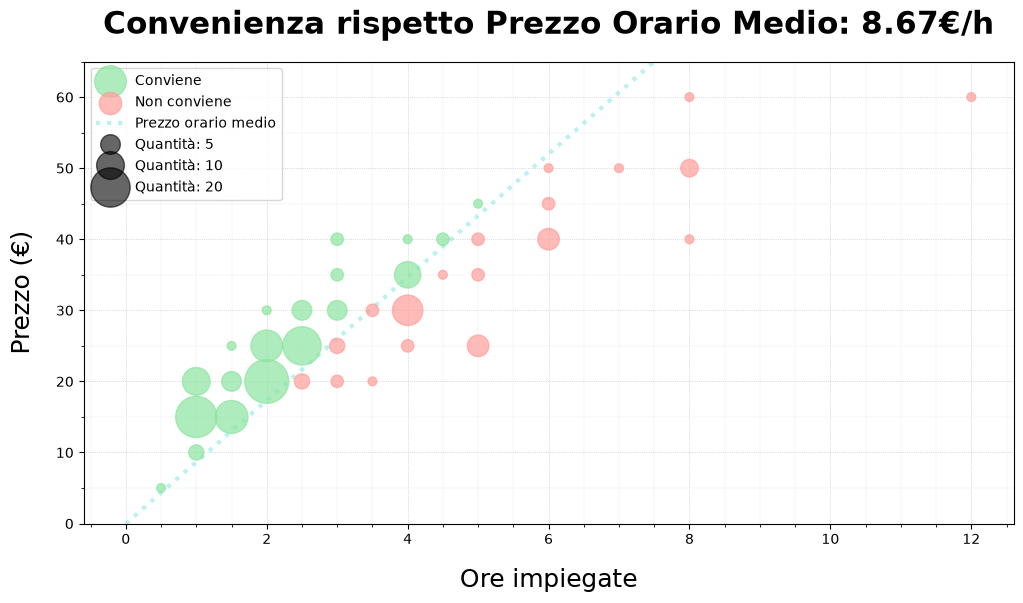

# Conclusioni

- Esclusi i mercatini, il periodo di maggior vendite è quello invernale.
- Ai mercatini tutti i tipi si vendono in modo simile, mentre tra le commissioni e i regali prevalgono ciondoli e orecchini.
- Il mercatino in rievocazione storica a Romans è quello che mi ha impegnato di più.
- In quasi tutte le tipologie prevale l'originalità nel design, meno che nei bracciali.
- I bracciali sono la categoria più pesante. Né la presenza di perline né l'originalità del desing è correlabile al peso del gioiello.
- Le ore di lavoro crescono assieme al peso.
- Il rapporto prezzo/ora è cresciuto all'inizio, per poi rallentare.
- Conviene concentrarsi su pezzi di massimo 3 ore di lavoro, mai più di 5.